# Task3_Exploratory Data Analysis

# GRIP @ The Spark Foundation

# Objective: Perform ‘Exploratory Data Analysis’ on the provided dataset ‘SampleSuperstore’

You are the business owner of the retail firm and want to see how your company is performing. You are interested in finding out the weak areas where you can work to make more profit. What all business problems you can derive by looking into the data? Link to the dataset: https://drive.google.com/file/d/1lV7is1B566UQPYzzY8R2ZmOritTW299S/view?usp=sharing

# Business Analytics:

Business Analytics is a combination of Data Analytics, Business Intelligence and Computer Programming.It is the science of analysing data to find out patterns that will be helpful in developing strategies. Its usage can be found in almost every industry. It is a process by which businesses use statistical methods and technologies for analyzing historical data in order to gain new insight and improve strategic decision making.

```python
import pandas as pd
import numpy as np
import matplotlib.pyplot as plt
import seaborn as sns
```

```python
%matplotlib inline
```

```python
df=pd.read_csv('SampleSuperstore.csv')
df.head()
```

|  | Ship Mode | Segment | Country | City | State | Postal Code | Region | Category | Sub-Category | Sales | Quantity | Discount | Profit |
| --- | --- | --- | --- | --- | --- | --- | --- | --- | --- | --- | --- | --- | --- |
| 0 | Second Class | Consumer | United States | Henderson | Kentucky | 42420 | South | Furniture | Bookcases | 261.9600 | 2 | 0.00 | 41.9136 |
| 1 | Second Class | Consumer | United States | Henderson | Kentucky | 42420 | South | Furniture | Chairs | 731.9400 | 3 | 0.00 | 219.5820 |
| 2 | Second Class | Corporate | United States | Los Angeles | California | 90036 | West | Office Supplies | Labels | 14.6200 | 2 | 0.00 | 6.8714 |
| 3 | Standard Class | Consumer | United States | Fort Lauderdale | Florida | 33311 | South | Furniture | Tables | 957.5775 | 5 | 0.45 | -383.0310 |
| 4 | Standard Class | Consumer | United States | Fort Lauderdale | Florida | 33311 | South | Office Supplies | Storage | 22.3680 | 2 | 0.20 | 2.5164 |

```python
df.shape  #This will tell us the size of the dataset
```

```
(9994, 13)
```

```python
df.info()  #General information of all the columns
```

```
<class 'pandas.core.frame.DataFrame'>
RangeIndex: 9994 entries, 0 to 9993
Data columns (total 13 columns):
 #   Column        Non-Null Count  Dtype
---  ------        --------------  -----
 0   Ship Mode     9994 non-null   object
 1   Segment       9994 non-null   object
 2   Country       9994 non-null   object
 3   City          9994 non-null   object
 4   State         9994 non-null   object
 5   Postal Code   9994 non-null   int64
 6   Region        9994 non-null   object
 7   Category      9994 non-null   object
 8   Sub-Category  9994 non-null   object
 9   Sales         9994 non-null   float64
 10  Quantity      9994 non-null   int64
 11  Discount      9994 non-null   float64
 12  Profit        9994 non-null   float64
dtypes: float64(3), int64(2), object(8)
memory usage: 1015.1+ KB
```

```python
df.describe()   #for the mathematical statistics of all the integer or float columns.
```

|  | Postal Code | Sales | Quantity | Discount | Profit |
| --- | --- | --- | --- | --- | --- |
| count | 9994.000000 | 9994.000000 | 9994.000000 | 9994.000000 | 9994.000000 |
| mean | 55190.379428 | 229.858001 | 3.789574 | 0.156203 | 28.656896 |
| std | 32063.693350 | 623.245101 | 2.225110 | 0.206452 | 234.260108 |
| min | 1040.000000 | 0.444000 | 1.000000 | 0.000000 | -6599.978000 |
| 25% | 23223.000000 | 17.280000 | 2.000000 | 0.000000 | 1.728750 |
| 50% | 56430.500000 | 54.490000 | 3.000000 | 0.200000 | 8.666500 |
| 75% | 90008.000000 | 209.940000 | 5.000000 | 0.200000 | 29.364000 |
| max | 99301.000000 | 22638.480000 | 14.000000 | 0.800000 | 8399.976000 |

```python
df.isnull().sum()  #To find if there are any null values present.
```

```
Ship Mode       0
Segment         0
Country         0
City            0
State           0
Postal Code     0
Region          0
Category        0
Sub-Category    0
Sales           0
Quantity        0
Discount        0
Profit          0
dtype: int64
```

```python
df.duplicated().sum()  #To know if there are any duplicate values present or not
```

```
17
```

```python
df.drop_duplicates(subset=None, keep='first', inplace=True)  # Dropping the duplicate values.
```

```python
df.duplicated().sum()
```

```
0
```

```python
df.shape
```

```
(9977, 13)
```

```python
df['Postal Code']= df['Postal Code'].astype('category')
#Converting this feature into category data type
```

# Exploratory Data Analysis

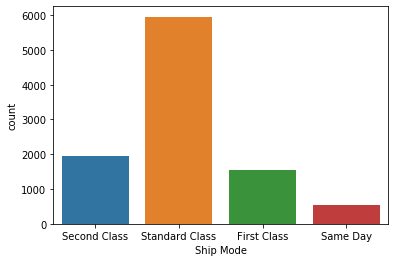

```python
sns.countplot(x=df['Ship Mode'])
```

From the above graph, we can say that maximum Ship Mode is of "Standard Class" and minimum is of "Same Day".

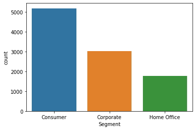

```python
sns.countplot(x=df['Segment'])
```

We find that the max segment is of the "Consumer" and minimum is of "Home Office".

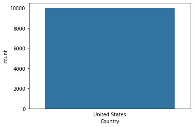

```python
sns.countplot(x=df['Country'])
```

This shows the data contains the information only about "United States".

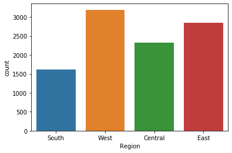

```python
sns.countplot(x=df['Region'])
```

This shows the most of the entries are form the "West" Region of United States.

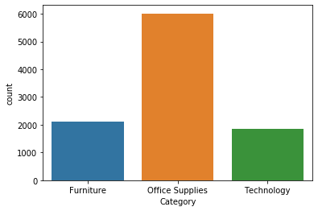

```python
sns.countplot(x=df['Category'])
```

Most of the categories of data in the dataset are from "Office Supplies".

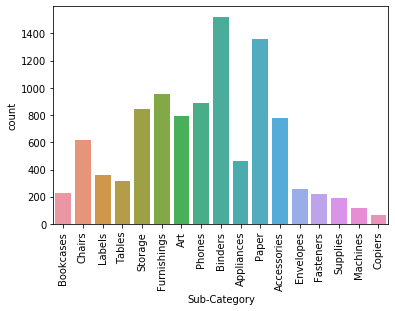

```python
sns.countplot(x=df['Sub-Category'])
plt.xticks(rotation=90)
```

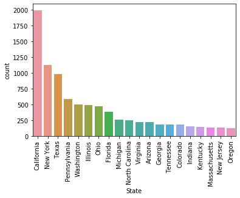

```python
sns.countplot(x=df['State'],order=(df['State'].value_counts().head(20)).index)
plt.xticks(rotation=90)
```

Maximum number of people are from "California" and "New York".

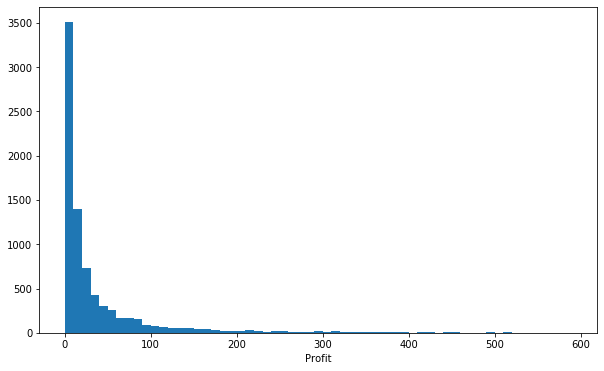

```python
plt.figure(figsize=(10,6))
plt.hist(df['Profit'],bins=(np.arange(0,600,10)))
plt.xlabel("Profit")
```

Hence we find that maximum profit lies in the range of 0-100.

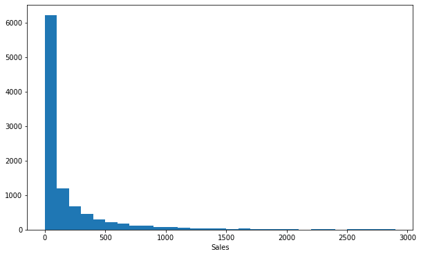

```python
plt.figure(figsize=(10,6))
plt.hist(df['Sales'],bins=(np.arange(0,3000,100)))
plt.xlabel("Sales")
```

This shows that the maximum sales range from 0-400.

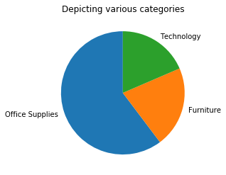

```python
# Pie Chart for finding out the major category.

plt.pie(df['Category'].value_counts(),labels= df['Category'].value_counts().index, startangle=90)
plt.title("Depicting various categories")
```

This shows that the major category is the "Office supplies".

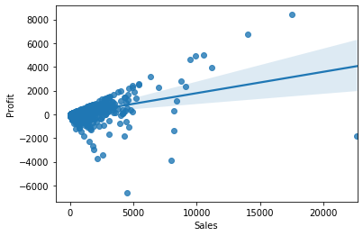

```python
sns.regplot(df['Sales'],df['Profit'])
```

The above regression plot shows that with increase with Sales, Profit also increases somehow. Since it is not in linear relation, we can't say that both are directly proportional!!

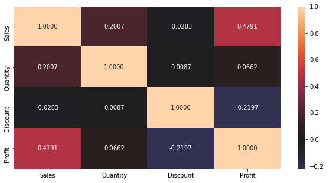

```python
# Heatmap to know about the correlation between different features in the given dataset.

num_data=['Sales','Quantity','Discount','Profit']
plt.figure(figsize=(10,5))
sns.heatmap(df[num_data].corr(),annot=True, fmt='.4f',center=0)
```

A correlation is a statistical measurement of the relationship between two variables. Possible correlations range from +1 to –1. A zero correlation indicates that there is no relationship between the variables.

Hence we come to know that the correlation between "Profit" and "Sales" is "0.4791". This shows that there is a positive relation between them.

Correlation between "Profit" and "Discount" is "-0.2197". This means that there is a weak negative relation between both of these numeric features.

# Insights derived from the above EDA: